#### Study the asymmetry of the edges in the specialty referral matrix.

We are studying a small graph, where each node is a primary specialty (e.g. PREVENTATIVE MEDICINE). Then, an “edge” from one specialty to another specialty represents a referral from a doctor of the first type, to a doctor of the second type. In a sample of 100k edges, there were 74 unique primary specialties. To accumulate edge strength, I used “two logs” as was done in the zip code graph. You can see my code here. You can download the data from the following url.

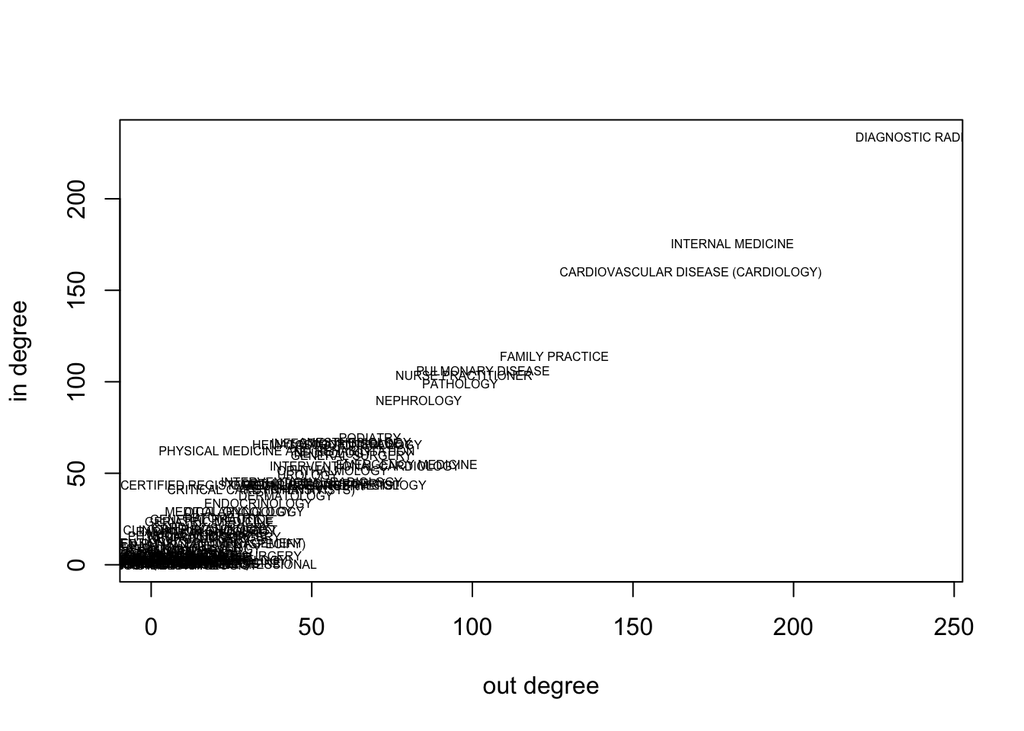

```r
rm(list = ls())
library(Matrix)
library(igraph)
load(url("http://pages.stat.wisc.edu/~karlrohe/netsci/data/specialty.RData"))
A = as.matrix(A) # it used to be a sparse matrix "dgCMatrix", even though it isn't that sparse.
rs = rowSums(A); cs = colSums(A)
plot(rs,cs, xlab= "out degree", ylab = "in degree", col = "white")
text(rs, cs, labels=colnames(A), cex = .5)
```

```r
ors = order(rs)
cbind(colnames(A)[ors], round(rs[ors],1))
```

```
##                                                [,1]
## CERTIFIED NURSE MIDWIFE                        "CERTIFIED NURSE MIDWIFE"
## ORAL SURGERY (DENTIST ONLY)                    "ORAL SURGERY (DENTIST ONLY)"
## REGISTERED DIETITIAN OR NUTRITION PROFESSIONAL "REGISTERED DIETITIAN OR NUTRITION PROFESSIONAL"
## SPEECH LANGUAGE PATHOLOGIST                    "SPEECH LANGUAGE PATHOLOGIST"
## ADDICTION MEDICINE                             "ADDICTION MEDICINE"
## GERIATRIC PSYCHIATRY                           "GERIATRIC PSYCHIATRY"
## PREVENTATIVE MEDICINE                          "PREVENTATIVE MEDICINE"
## GYNECOLOGICAL ONCOLOGY                         "GYNECOLOGICAL ONCOLOGY"
## NEUROPSYCHIATRY                                "NEUROPSYCHIATRY"
## SPORTS MEDICINE                                "SPORTS MEDICINE"
## SLEEP LABORATORY/MEDICINE                      "SLEEP LABORATORY/MEDICINE"
## PERIPHERAL VASCULAR DISEASE                    "PERIPHERAL VASCULAR DISEASE"
## OSTEOPATHIC MANIPULATIVE MEDICINE              "OSTEOPATHIC MANIPULATIVE MEDICINE"
## SURGICAL ONCOLOGY                              "SURGICAL ONCOLOGY"
## HOSPICE/PALLIATIVE CARE                        "HOSPICE/PALLIATIVE CARE"
## AUDIOLOGIST                                    "AUDIOLOGIST"
## HAND SURGERY                                   "HAND SURGERY"
## ANESTHESIOLOGY ASSISTANT                       "ANESTHESIOLOGY ASSISTANT"
## OCCUPATIONAL THERAPY                           "OCCUPATIONAL THERAPY"
## CLINICAL NURSE SPECIALIST                      "CLINICAL NURSE SPECIALIST"
## PEDIATRIC MEDICINE                             "PEDIATRIC MEDICINE"
## ALLERGY/IMMUNOLOGY                             "ALLERGY/IMMUNOLOGY"
## PHYSICIAN ASSISTANT                            "PHYSICIAN ASSISTANT"
## COLORECTAL SURGERY (PROCTOLOGY)                "COLORECTAL SURGERY (PROCTOLOGY)"
## CLINICAL SOCIAL WORKER                         "CLINICAL SOCIAL WORKER"
## PLASTIC AND RECONSTRUCTIVE SURGERY             "PLASTIC AND RECONSTRUCTIVE SURGERY"
## CHIROPRACTIC                                   "CHIROPRACTIC"
## OBSTETRICS/GYNECOLOGY                          "OBSTETRICS/GYNECOLOGY"
## HEMATOLOGY                                     "HEMATOLOGY"
## UNDEFINED PHYSICIAN TYPE (SPECIFY)             "UNDEFINED PHYSICIAN TYPE (SPECIFY)"
## PHYSICAL THERAPY                               "PHYSICAL THERAPY"
## INTERVENTIONAL PAIN MANAGEMENT                 "INTERVENTIONAL PAIN MANAGEMENT"
## PAIN MANAGEMENT                                "PAIN MANAGEMENT"
## CLINICAL PSYCHOLOGIST                          "CLINICAL PSYCHOLOGIST"
## NEUROSURGERY                                   "NEUROSURGERY"
## RADIATION ONCOLOGY                             "RADIATION ONCOLOGY"
## NUCLEAR MEDICINE                               "NUCLEAR MEDICINE"
## GERIATRIC MEDICINE                             "GERIATRIC MEDICINE"
## CARDIAC SURGERY                                "CARDIAC SURGERY"
```

[output cut: 95 more lines]

```
## INFECTIOUS DISEASE                             "57.6"
## GENERAL SURGERY                                "62.4"
## GASTROENTEROLOGY                               "63.2"
## ANESTHESIOLOGY                                 "63.5"
## INTERVENTIONAL CARDIOLOGY                      "66.5"
## PODIATRY                                       "68.1"
## EMERGENCY MEDICINE                             "79.6"
## NEPHROLOGY                                     "83.3"
## PATHOLOGY                                      "96.2"
## NURSE PRACTITIONER                             "97.4"
## PULMONARY DISEASE                              "103.4"
## FAMILY PRACTICE                                "125.6"
## CARDIOVASCULAR DISEASE (CARDIOLOGY)            "168"
## INTERNAL MEDICINE                              "181"
## DIAGNOSTIC RADIOLOGY                           "242.9"
```

Are edges reciprocal?

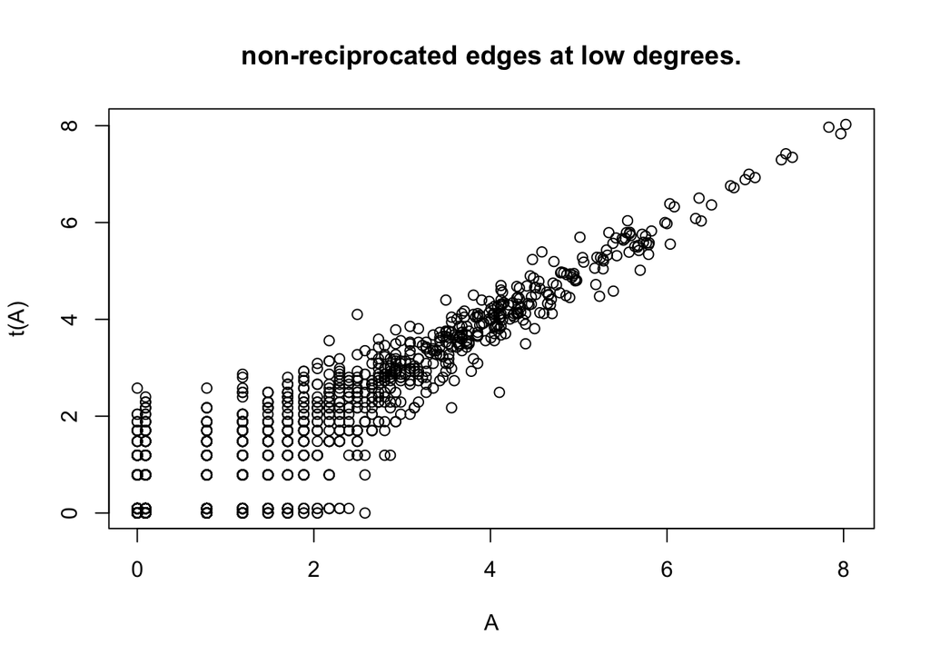

```r
plot(A,t(A), main = "non-reciprocated edges at low degrees.")
```

```r
bA = matrix(0, nrow = nrow(A), ncol = ncol(A))
bA[A>.5] = 1
nonrecA = bA*(1-t(bA))
nonrecEdges = which(nonrecA == 1, arr.ind = T)
# the first column makes some referrals to the second column, but it is much less likely in the other direction.
cbind(colnames(A)[nonrecEdges[,1]], colnames(A)[nonrecEdges[,2]])
```

```
##        [,1]
##   [1,] "NURSE PRACTITIONER"
##   [2,] "GASTROENTEROLOGY"
##   [3,] "PLASTIC AND RECONSTRUCTIVE SURGERY"
##   [4,] "CLINICAL SOCIAL WORKER"
##   [5,] "PAIN MANAGEMENT"
##   [6,] "DERMATOLOGY"
##   [7,] "PERIPHERAL VASCULAR DISEASE"
##   [8,] "OSTEOPATHIC MANIPULATIVE MEDICINE"
##   [9,] "SPORTS MEDICINE"
##  [10,] "PLASTIC AND RECONSTRUCTIVE SURGERY"
##  [11,] "COLORECTAL SURGERY (PROCTOLOGY)"
##  [12,] "HEMATOLOGY"
##  [13,] "CLINICAL SOCIAL WORKER"
##  [14,] "SURGICAL ONCOLOGY"
```

[output cut: 361 more lines]

What is the page rank? Imagine a Markov chain on the specialties. You get randomly referred around this network. Where are you likely to land?

```r
g= graph.adjacency(A,mode= "directed", weighted = T)
pr = page.rank(g,directed = T)
sort(pr$vec)
```

```
##                    SPEECH LANGUAGE PATHOLOGIST
##                                    0.002077967
##                             ADDICTION MEDICINE
##                                    0.002105919
##                    ORAL SURGERY (DENTIST ONLY)
##                                    0.002107728
## REGISTERED DIETITIAN OR NUTRITION PROFESSIONAL
##                                    0.002161430
##                          PREVENTATIVE MEDICINE
##                                    0.002179199
##                        CERTIFIED NURSE MIDWIFE
##                                    0.002327073
##                    PERIPHERAL VASCULAR DISEASE
##                                    0.002422320
##                                NEUROPSYCHIATRY
##                                    0.002462197
##              OSTEOPATHIC MANIPULATIVE MEDICINE
##                                    0.002475945
##                                   HAND SURGERY
##                                    0.002507377
##                                SPORTS MEDICINE
##                                    0.002525492
##                           GERIATRIC PSYCHIATRY
##                                    0.002684366
##                COLORECTAL SURGERY (PROCTOLOGY)
##                                    0.002708545
##                             PEDIATRIC MEDICINE
##                                    0.002787374
##                       ANESTHESIOLOGY ASSISTANT
##                                    0.003011476
##                              SURGICAL ONCOLOGY
##                                    0.003088967
##                                    AUDIOLOGIST
##                                    0.003321303
##                         GYNECOLOGICAL ONCOLOGY
##                                    0.003338767
##                      CLINICAL NURSE SPECIALIST
##                                    0.003365498
##                      SLEEP LABORATORY/MEDICINE
##                                    0.003486039
```

[output cut: 93 more lines]

```
##                                    0.028940651
##                                      PATHOLOGY
##                                    0.033222916
##                              PULMONARY DISEASE
##                                    0.035433680
##                             NURSE PRACTITIONER
##                                    0.036888685
##                                FAMILY PRACTICE
##                                    0.039854253
##            CARDIOVASCULAR DISEASE (CARDIOLOGY)
##                                    0.054053173
##                              INTERNAL MEDICINE
##                                    0.063283769
##                           DIAGNOSTIC RADIOLOGY
##                                    0.090427380
```

Before reading the next steps, you might read the lecture notes on the eigendecomposition and the svd.  
The algorithm “di-sim” explored here is described in [this paper](http://arxiv.org/abs/1204.2296).

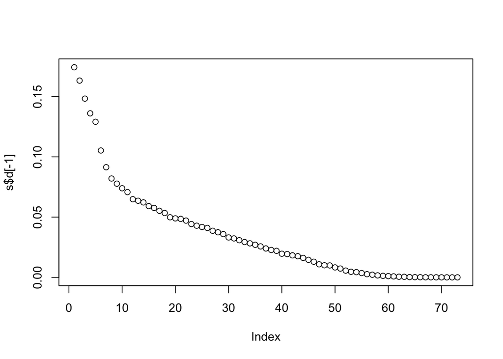

```r
Drow = Diagonal(n = nrow(A), 1/sqrt(rs + mean(rs)))
Dcol = Diagonal(n = ncol(A), 1/sqrt(cs + mean(cs)))
L = Drow%*%A%*%Dcol
s = svd(L)
plot(s$d[-1])
```

```r
k = 3
u = s$u[,1:k]; v = s$v[,1:k]
n = nrow(A)
un = t(apply(u,1, function(x) return(x/sqrt(sum(x^2)+1/n))))
vn = t(apply(v,1, function(x) return(x/sqrt(sum(x^2)+1/n))))
km = kmeans(rbind(un,vn), centers = k,nstart = 100)
uclust = km$clust[1:n]
vclust = km$clust[-(1:n)]
table(uclust,vclust)
```

```
##       vclust
## uclust  1  2  3
##      1  0 34  4
##      2  7 13  0
##      3  1  0 15
```

If this network was highly symmetric (i.e. reciprocal) what would that table look like?

```r
nm = colnames(A)
nm[uclust == 1]
```

```
##  [1] "CARDIAC SURGERY"
##  [2] "UROLOGY"
##  [3] "CERTIFIED REGISTERED NURSE ANESTHETIST"
##  [4] "PHYSICAL MEDICINE AND REHABILITATION"
##  [5] "ORTHOPEDIC SURGERY"
##  [6] "DERMATOLOGY"
##  [7] "OPTOMETRY"
##  [8] "ENDOCRINOLOGY"
##  [9] "THORACIC SURGERY"
## [10] "RHEUMATOLOGY"
## [11] "ALLERGY/IMMUNOLOGY"
## [12] "OSTEOPATHIC MANIPULATIVE MEDICINE"
## [13] "GENERAL PRACTICE"
## [14] "NEUROSURGERY"
## [15] "PSYCHIATRY"
```

[output cut: 23 more lines]

```r
nm[vclust == 1]
```

```
## [1] "INTERNAL MEDICINE"
## [2] "CARDIOVASCULAR DISEASE (CARDIOLOGY)"
## [3] "DIAGNOSTIC RADIOLOGY"
## [4] "PATHOLOGY"
## [5] "FAMILY PRACTICE"
## [6] "NURSE PRACTITIONER"
## [7] "AUDIOLOGIST"
## [8] "OCCUPATIONAL THERAPY"
```

Note that $u$ corresponds to sending patterns and $v$ corresponds to receiving patterns.